# 6 Redes de neuronas artificiales recurrentes

Las redes de neuronas artificiales recurrentes (RNN por sus siglas en inglés) son un tipo de redes neuronales diseñadas para trabajar con datos secuenciales. A diferencia de las redes neuronales tradicionales tienen una memoria interna capaz de recordar información de una secuencia temporal de entradas, y utilizar esa información para predecir nuevos valores de la serie o clasificarla. Esto las hace ideales para tareas de predicción de series temporales, traducción de textos o audios, y procesamiento del lenguaje natural entre otras.

En esta práctica veremos cómo funcionan estas redes neuronales y aprenderemos a implementarlas con el paquete `Lux` de Julia.

## 6.1 Ejercicios Resueltos

Para la realización de esta práctica se requieren los siguientes paquetes:

```julia
using CSV  # Para la lectura de archivos CSV.
using DataFrames  # Para el manejo de datos tabulares.
using GLMakie  # Para el dibujo de gráficas.
using Random  # Para la generación de números aleatorios.
using Lux  # Para la implementación de redes neuronales.
using Zygote  # Cálculo automático de derivadas y gradientes.
using Optimisers # Para la optimización de funciones.
using Statistics # Para las funciones de coste.
```

**Ejercicio 6.1** La sucesión de Fibonacci es una sucesión recurrente que se define como

$$a_1 = 1,\quad a_2 =1, \quad a_n = a_{n-1} + a_{n-2}\quad \forall n\geq 3.$$

1. Construir una función para generar la sucesión de Fibonacci.

   **TipSolución**

   ```julia
   function fibonacci(n::Int)
       a = zeros(Float32, n)
       a[1] = 1
       a[2] = 1
       for i in 3:n
           a[i] = a[i-1] + a[i-2]
       end
       return a
   end
   ```

   ```
   fibonacci (generic function with 1 method)
   ```

   **TipSolución**

   ```julia
   fib = fibonacci(25)
   tamaño = 4
   n = 25 - tamaño
   # La red esperar una entrada con dimensiones (características, tamaño, lote).
   X =  Array{Float32}(undef, 1, tamaño, n)
   Y = Array{Float32}(undef, 1, n)
   for i = 1:n
       ventana = fib[i:i+tamaño-1]
       etiqueta = fib[i+tamaño]
       X[1, : , i] .= ventana
       Y[1, i] = etiqueta
   end
   ```

3. Definir una red neuronal con una neurona recurrente con un estado oculto de tamaño 1, sin término independiente (*bias*). Inicializar la red con pesos aleatorios.

   **TipSolución**

   ```julia
   using Lux, Random

   modelo = Chain(
       Recurrence(RNNCell(1 => 1, identity; use_bias = false); return_sequence = false)
   )

   rng = Random.default_rng()
   # Semilla aleatoria para reproducibilidad
   Random.seed!(rng, 1234)
   ps, st = Lux.setup(rng, modelo)
   ```

   ```
   ((layer_1 = (weight_ih = Float32[-1.7194579;;], weight_hh = Float32[1.174417;;]),), (layer_1 = (rng = TaskLocalRNG(),),))
   ```

4. Definir como función de coste el error cuadrático medio para todas las secuencias del conjunto de entrenamiento.

   **TipSolución**

   ```julia
   using Statistics
   function coste(ps, st, X, Y)
       ŷ, estado = modelo(X, ps, st)          # ŷ: (1, batch)
       return mean((ŷ .- Y).^2)
   end

   coste(ps, st, X, Y)
   ```

   ```
   6.2632223f9
   ```

5. Entrenar la red neuronal con el algoritmo de optimización `Adam` tomando una tasa de aprendizaje 0.1. Realizar 200 épocas.

   **TipSolución**

   ```julia
   using Optimisers, Zygote
   opt = Optimisers.setup(Optimisers.Adam(0.1f0), ps)

   nepocas = 200
   costes = []
   for epoca in 1:nepocas
       # gradiente de la red con respecto a los parámetros
       gs = first(Zygote.gradient(p -> coste(p, st, X, Y), ps))
       opt, ps = Optimisers.update(opt, ps, gs)
       push!(costes, coste(ps, st, X, Y))
       println("Época $epoca | coste = ", costes[end])
   end
   ```

   ```
   Época 1 | coste = 5.0130447e9
   Época 2 | coste = 4.046983e9
   Época 3 | coste = 3.3034327e9
   Época 4 | coste = 2.7312077e9
   Época 5 | coste = 2.2893059e9
   Época 6 | coste = 1.94581e9
   Época 7 | coste = 1.6764061e9
   Época 8 | coste = 1.4628404e9
   Época 9 | coste = 1.2915259e9
   Época 10 | coste = 1.1523862e9
   Época 11 | coste = 1.0379493e9
   Época 12 | coste = 9.4265696e8
   Época 13 | coste = 8.623539e8
   Época 14 | coste = 7.9391226e8
   Época 15 | coste = 7.349589e8
   Época 16 | coste = 6.836777e8
   Época 17 | coste = 6.386652e8
   Época 18 | coste = 5.9882643e8
   Época 19 | coste = 5.632986e8
   Época 20 | coste = 5.313949e8
   Época 21 | coste = 5.0256346e8
   Época 22 | coste = 4.7635606e8
   Época 23 | coste = 4.5240582e8
   Época 24 | coste = 4.3040934e8
   Época 25 | coste = 4.101142e8
   Época 26 | coste = 3.913082e8
   Época 27 | coste = 3.7381197e8
   Época 28 | coste = 3.5747312e8
   Época 29 | coste = 3.4216106e8
   Época 30 | coste = 3.277637e8
   Época 31 | coste = 3.141841e8
   Época 32 | coste = 3.0133814e8
   Época 33 | coste = 2.891527e8
   Época 34 | coste = 2.77564e8
   Época 35 | coste = 2.665161e8
   Época 36 | coste = 2.5595997e8
   Época 37 | coste = 2.458527e8
   Época 38 | coste = 2.3615629e8
   Época 39 | coste = 2.268375e8
   Época 40 | coste = 2.1786688e8
   ```

   [output cut: 145 more lines]

   ```
   Época 186 | coste = 268.0682
   Época 187 | coste = 225.7752
   Época 188 | coste = 187.4945
   Época 189 | coste = 153.36887
   Época 190 | coste = 123.32797
   Época 191 | coste = 97.2789
   Época 192 | coste = 75.056725
   Época 193 | coste = 56.43496
   Época 194 | coste = 41.149002
   Época 195 | coste = 28.87258
   Época 196 | coste = 19.250816
   Época 197 | coste = 12.009598
   Época 198 | coste = 6.7831855
   Época 199 | coste = 3.2605946
   Época 200 | coste = 1.1491588
   ```

6. Dibujar la evolución de los costes durante el proceso de entrenamiento.

   **TipSolución**

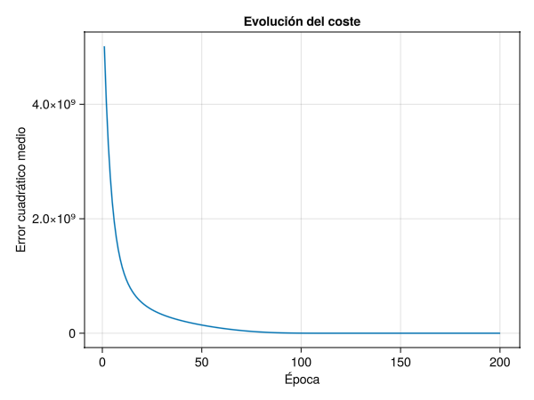

   ```julia
   using GLMakie
   fig = Figure()
   ax = Axis(fig[1, 1], xlabel = "Época", ylabel = "Error cuadrático medio", title = "Evolución del coste")
   lines!(ax, costes)
   fig
   ```

7. Usar la red neuronal entrenada para predecir el siguiente término de la serie de Fibonacci a partir de los 4 últimos términos de la serie.

   **TipSolución**

   ```julia
   fib = fibonacci(30)
   X_test = reshape(fib[end-tamaño : end-1], 1, tamaño, 1)

   y_test, _ = modelo(X_test, ps, st)
   println("Predicción del término 30: ",  y_test[1, 1])
   println("Término 30 de la sucesión de Fibonacci: ", fib[end])
   ```

   ```
   Predicción del término 30: 831997.2
   Término 30 de la sucesión de Fibonacci: 832040.0
   ```

8. Mostrar los pesos de la red neuronal entrenada.

   **TipSolución**

   ```julia
   println("Pesos de la entrada de la red neuronal:", ps.layer_1.weight_ih)
   println("Pesos del estado de la red neuronal:", ps.layer_1.weight_hh)
   ```

   ```
   Pesos de la entrada de la red neuronal:Float32[1.662782;;]
   Pesos del estado de la red neuronal:Float32[-0.04483252;;]
   ```

**Ejercicio 6.2** El fichero [`stock.csv`](https://aprendeconalf.es/aprendizaje-automatico-practicas-julia/datos/) contiene los precios al cierre de las acciones de una empresas en bolsa de valores de los 300 primeros días del año 2020.

1. Cargar el conjunto de datos y dibujar la serie temporal.

   **TipSolución**

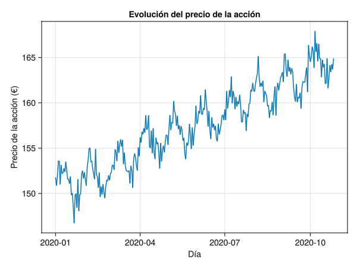

   ```julia
   using CSV, DataFrames, GLMakie

   # Cargamos el conjunto de datos en un data frame
   df = CSV.read("datos/stock.csv", DataFrame)

   # Creamos el gráfico de la evolución
   fig = Figure()
   ax = Axis(fig[1, 1], xlabel = "Día", ylabel = "Precio de la acción (€)", title = "Evolución del precio de la acción")

   lines!(ax, df.dia, df.precio)
   fig
   ```

2. Normalizar el conjunto de datos.

   **TipSolución**

   ```julia
   using Statistics

   # Simple normalization (z-score)
   μ = mean(df.precio)
   σ = std(df.precio)
   serie = (df.precio .- μ) ./ σ
   ```

   ```
   300-element Vector{Float64}:
    -1.2770239698472932
    -1.4749432268197025
    -1.2481144154580652
    -0.8745140202741842
    -0.8789616440263692
    -1.4460336724304748
    -0.9679141190701513
    -1.1814000591752272
    -1.1591619404142832
    -1.054642782237841
    -1.1391476335294317
    -0.8923045152829369
    -1.1035666435119202
     ⋮
     1.4249074596075517
     1.5049646871469575
     1.031292757538819
     1.0379641931671029
     1.6472886472170039
     0.9112069162297167
     1.1469309750957366
     1.4782789446338223
     1.3137168658028255
     1.5027408752708586
     1.3759835983334725
     1.6450648353409114
   ```

   **TipSolución**

   ```julia
   function crear_secuencias(serie, tamaño)
       # Número de ventanas
       n = length(serie) - tamaño

       # X: (características=1, tamaño=seq_len, lotes=n)
       X = Array{Float32}(undef, 1, tamaño, n)
       # Y: (etiquetas=1, lotes=n)
       Y = Array{Float32}(undef, 1, n)

       for i in 1:n
           ventana = serie[i : i + tamaño - 1]
           etiqueta = serie[i + tamaño]
           X[1, :, i] .= ventana
           Y[1, i] = etiqueta
       end

       return X, Y
   end

   X, Y = crear_secuencias(serie, 50)
   ```

   ```
   (Float32[-1.2770239 -1.4749433 … -1.7551435 -1.501629;;; -1.4749433 -1.2481145 … -1.501629 -1.6973244;;; -1.2481145 -0.87451404 … -1.6973244 -1.4393623;;; … ;;; 1.7607031 1.3515216 … 1.478279 1.3137169;;; 1.3515216 1.1980786 … 1.3137169 1.5027409;;; 1.1980786 1.6117077 … 1.5027409 1.3759836], Float3…
   ```

4. Dividir el conjunto de secuencias en un conjunto de entrenamiento con las 200 primeras secuencias y otro de prueba con las 50 restantes.

   **TipSolución**

   ```julia
   Xentrenamiento, Yentrenamiento = X[:, :, 1:200], Y[:, 1:200]
   Xtest, Ytest = X[:, :, 201:end], Y[:, 201:end]
   ```

   ```
   (Float32[0.08839652 0.09062033 … 1.3515216 1.1980786;;; 0.09062033 0.3797159 … 1.1980786 1.6117077;;; 0.3797159 0.29298723 … 1.6117077 1.3248359;;; … ;;; 1.7607031 1.3515216 … 1.478279 1.3137169;;; 1.3515216 1.1980786 … 1.3137169 1.5027409;;; 1.1980786 1.6117077 … 1.5027409 1.3759836], Float32[1.611…
   ```

5. Definir una red neuronal con una neurona recurrente con un estado oculto de tamaño 64 y una neurona densa de 1 salida. Inicializar la red con pesos aleatorios.

   **TipSolución**

   ```julia
   using Lux, Random
   modelo = Chain(
       Recurrence(RNNCell(1 => 64); return_sequence = false),
       Dense(64 => 1)
   )

   rng = Random.default_rng()
   # Semilla aletoria para reproducibilidad
   Random.seed!(rng, 1234)
   ps, st = Lux.setup(rng, modelo)
   ```

   ```
   ((layer_1 = (weight_ih = Float32[-0.21493223; 0.14680213; … ; 0.09006676; -0.29187012;;], weight_hh = Float32[0.16710633 -0.10049977 … -0.7339213 -0.44402117; -0.12605162 -0.42469883 … -0.2643636 -0.33319688; … ; -0.2543804 0.052617714 … -0.60686016 -0.4568765; 0.24136081 -0.34361988 … 0.12011717 0.…
   ```

6. Definir como función de coste el error cuadrático medio para todas las secuencias del conjunto de entrenamiento.

   **TipSolución**

   ```julia
   using Statistics
   function coste(ps, st, X, Y)
       ŷ, estado = modelo(X, ps, st)
       return mean((ŷ .- Y).^2)
   end

   coste(ps, st, X, Y)
   ```

   ```
   2.4999213f0
   ```

   **TipSolución**

   ```julia
   using Optimisers, Zygote
   opt = Optimisers.setup(Optimisers.Adam(0.01f0), ps)

   nepocas = 100
   costes = []
   for epoca in 1:nepocas
       # gradiente de la red con respecto a los parámetros
       gs = first(Zygote.gradient(p -> coste(p, st, Xentrenamiento, Yentrenamiento), ps))
       opt, ps = Optimisers.update(opt, ps, gs)
       push!(costes, coste(ps, st, Xentrenamiento, Yentrenamiento))
       println("Época $epoca | coste = ", costes[end])
   end
   ```

   ```
   Época 1 | coste = 0.7120536
   Época 2 | coste = 0.58144593
   Época 3 | coste = 0.86751
   Época 4 | coste = 0.9924159
   Época 5 | coste = 0.8545057
   Época 6 | coste = 0.6759848
   Época 7 | coste = 0.5618811
   Época 8 | coste = 0.56183267
   Época 9 | coste = 0.6390394
   Época 10 | coste = 0.7087791
   Época 11 | coste = 0.7118296
   Época 12 | coste = 0.6544135
   Época 13 | coste = 0.5607798
   Época 14 | coste = 0.4915699
   Época 15 | coste = 0.49867082
   Época 16 | coste = 0.5568062
   Época 17 | coste = 0.5875028
   Época 18 | coste = 0.566299
   Época 19 | coste = 0.51768893
   Época 20 | coste = 0.4785608
   Época 21 | coste = 0.47465625
   Época 22 | coste = 0.49831668
   Época 23 | coste = 0.517101
   Época 24 | coste = 0.5072868
   Época 25 | coste = 0.4794915
   Época 26 | coste = 0.44851258
   Época 27 | coste = 0.4381218
   Época 28 | coste = 0.4442783
   Época 29 | coste = 0.4462868
   Época 30 | coste = 0.4242044
   Época 31 | coste = 0.38773945
   Época 32 | coste = 0.35950392
   Época 33 | coste = 0.34827664
   Época 34 | coste = 0.3276915
   Época 35 | coste = 0.28721783
   Época 36 | coste = 0.25264022
   Época 37 | coste = 0.2554782
   Época 38 | coste = 0.22638088
   Época 39 | coste = 0.20317441
   Época 40 | coste = 0.19642892
   ```

   [output cut: 45 more lines]

   ```
   Época 86 | coste = 0.068120345
   Época 87 | coste = 0.06778442
   Época 88 | coste = 0.06775368
   Época 89 | coste = 0.06764672
   Época 90 | coste = 0.06730844
   Época 91 | coste = 0.067337014
   Época 92 | coste = 0.06719287
   Época 93 | coste = 0.06740736
   Época 94 | coste = 0.06722504
   Época 95 | coste = 0.06719639
   Época 96 | coste = 0.06701797
   Época 97 | coste = 0.0668914
   Época 98 | coste = 0.066815436
   Época 99 | coste = 0.06673246
   Época 100 | coste = 0.06663198
   ```

8. Dibujar la evolución de los costes durante el proceso de entrenamiento.

   **TipSolución**

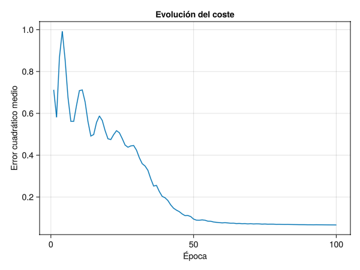

   ```julia
   using GLMakie
   fig = Figure()
   ax = Axis(fig[1, 1], xlabel = "Época", ylabel = "Error cuadrático medio", title = "Evolución del coste")
   lines!(ax, costes)
   fig
   ```

9. Predecir el precio de las acciones de los próximos 50 días usando el conjunto de prueba.

   **TipSolución**

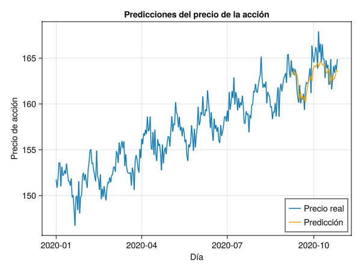

   ```julia
   y_test, _ = modelo(Xtest, ps, st)
   predicciones = y_test .* σ .+ μ

   fig = Figure()
   ax = Axis(fig[1,1], xlabel = "Día", ylabel = "Precio de acción", title = "Predicciones del precio de la acción")
   lines!(ax, df.dia, df.precio, label = "Precio real")
   lines!(ax, df.dia[251:end], vec(predicciones), label = "Predicción")
   axislegend(ax, position = :rb)
   fig
   ```